# Terrorism Summary in Turkey, 2016

Şule Kütükde

October 29, 2017

The data set can be downloaded [here](https://www.kaggle.com/START-UMD/gtd). Dataset consists of the global attacks that has been accepted as ‘terrorist attack’ with lots of variables. This research aims to demonstrate the terrorist attacks situation took place in Turkey, 2016.

- First Tidyverse should be loaded, then the raw data should be adressed.

```r
library("tidyverse")
globaldata<-read.csv(file="globalterrorismdb_0617dist.csv", header=TRUE)
```

- Turkey’s terror history can be summarized by years as demonstraded down below. Since most densely number of attacks occured in 2016, that year is examined in this research.

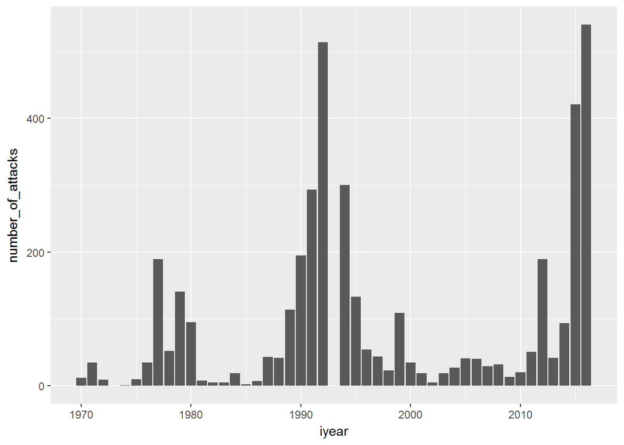

```r
turkeydata<-globaldata%>%
  filter(country_txt=="Turkey")%>%
  group_by(iyear,provstate,imonth,success,gname,targtype1_txt)%>%
  summarise(number_of_attacks=n())
ggplot(turkeydata, aes(x=iyear,y=number_of_attacks)) + geom_bar(stat = "identity")
```

- The chart down below filters out the year of 2016 and the countries that have witnessed higher than 100 attacks. The chart indicates that Turkey is in the top 18 countries that has been exposed to terrorist attacks in this dataset.

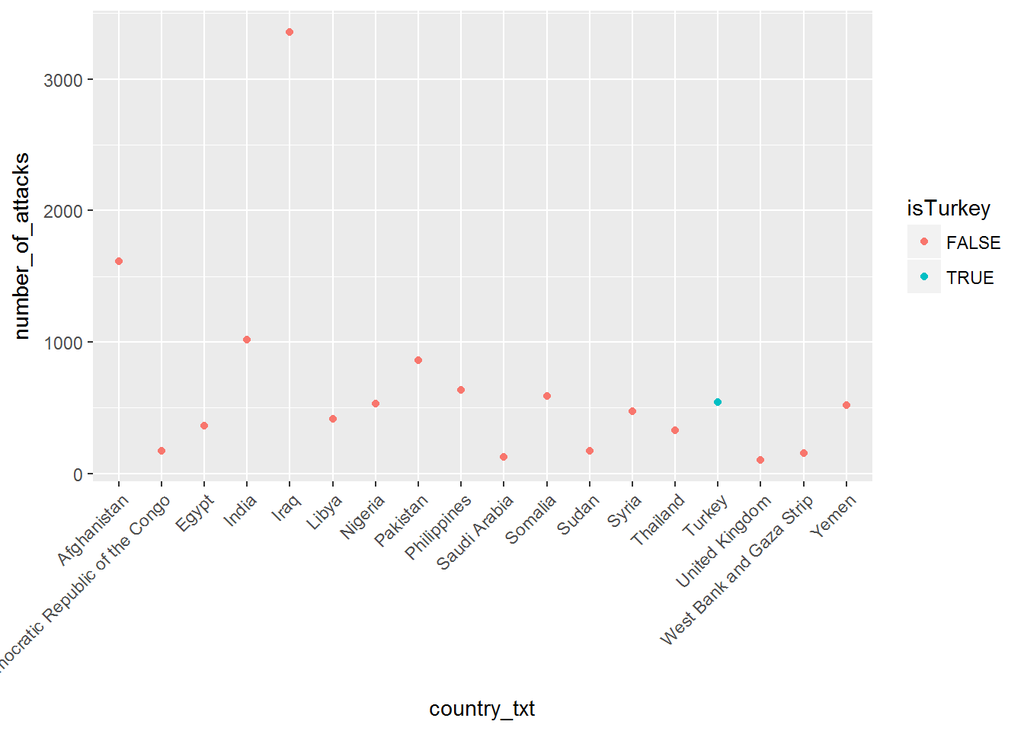

```r
globaldata16 <-globaldata%>%
  filter(iyear=="2016") %>%
  group_by(country_txt) %>%
  summarise(number_of_attacks=n())%>%
  filter(number_of_attacks>100)%>%
  arrange(desc(number_of_attacks))%>%
  mutate(isTurkey=(country_txt == "Turkey"))
ggplot(globaldata16, aes(x=country_txt,y=number_of_attacks)) +
  geom_point(aes(color=isTurkey))+
  theme(axis.text.x=element_text(angle=45,hjust=1,vjust=1))
```

- This chart shows that the successful attempts by Turkey’s cities. Accordingly, Istanbul the highest populated city in Turkey is the 5th most suffered city from attacks.

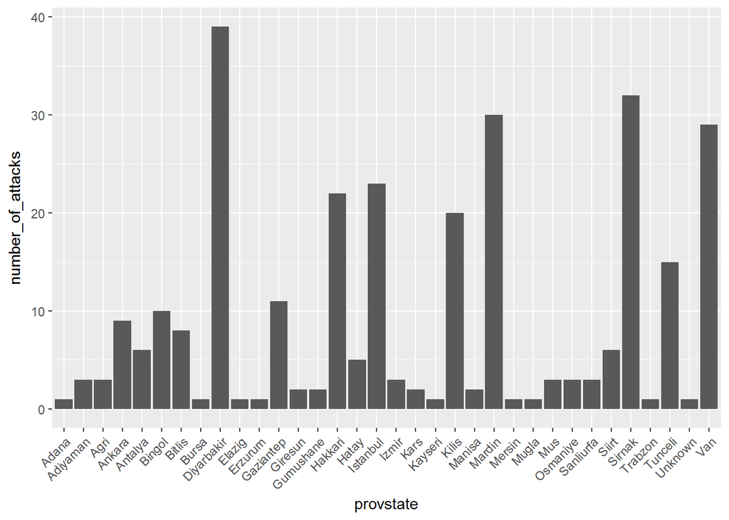

```r
turkeydata16_sehirleregore<-turkeydata%>%
  filter(iyear=="2016",success=="1")%>%
  group_by(provstate)%>%
  summarise(number_of_attacks=n())
ggplot(turkeydata16_sehirleregore, aes(x=provstate,y=number_of_attacks)) +
  geom_bar(stat = "identity")+
  theme(axis.text.x=element_text(angle=45,hjust=1,vjust=1))
```

- Here this chart shows the ratio of successful attempts.

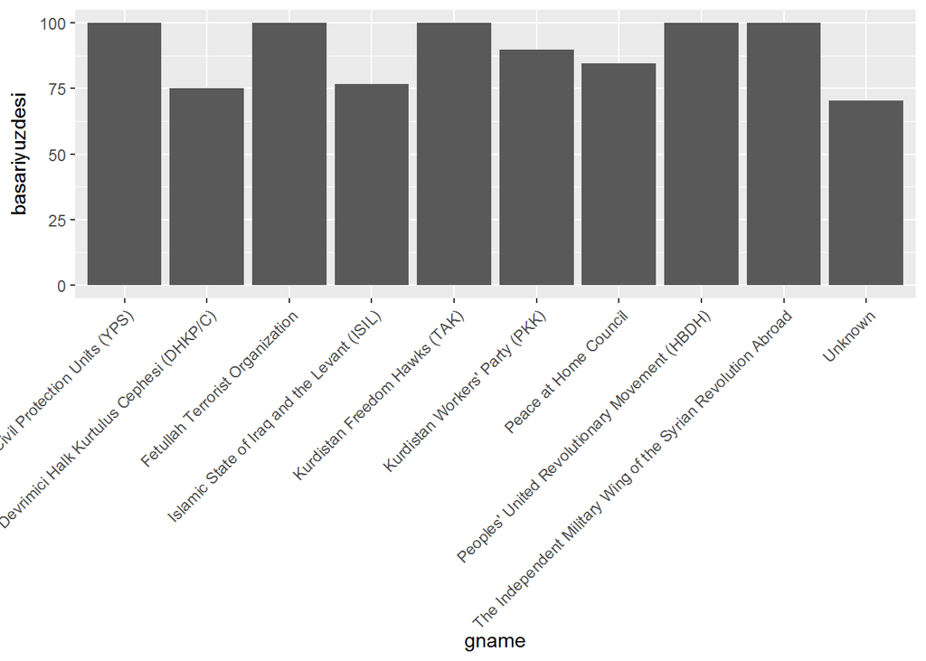

```r
turkeydata16_basariorani<-turkeydata%>%
  filter(iyear=="2016")%>%
  group_by(gname)%>%
  summarise(number_of_attacks=n(),basarililar=sum(success))%>%
  mutate(basariyuzdesi=(basarililar/number_of_attacks)*100)
ggplot(turkeydata16_basariorani, aes(x=gname,y=basariyuzdesi)) +
  geom_bar(stat = "identity")+
  theme(axis.text.x=element_text(angle=45,hjust=1,vjust=1))
```

- Not suprisingly, PKK has the highest number of attacks in 2016.

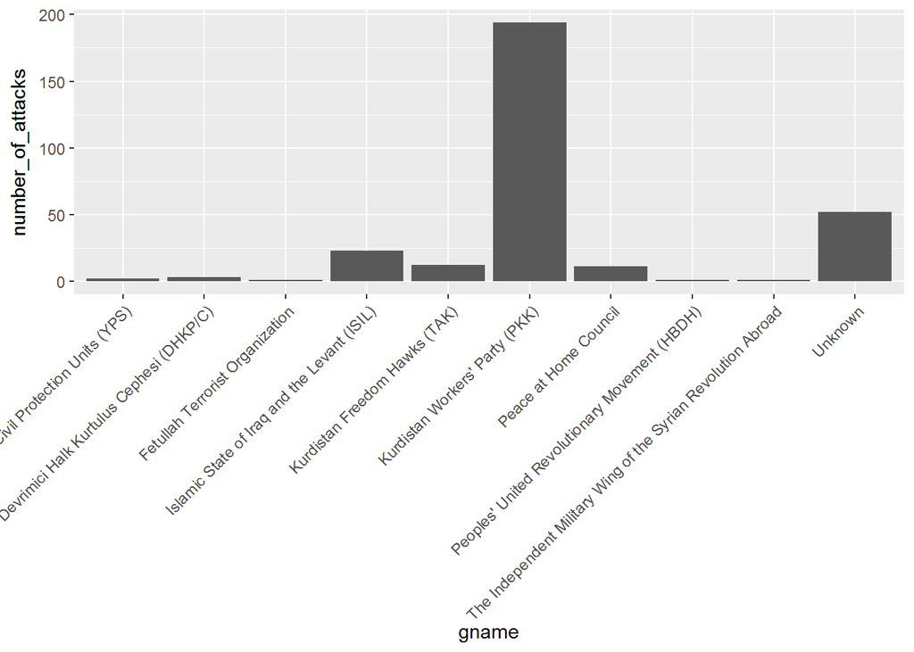

```r
#orgutler
turkeydata16_orgutler<-turkeydata%>%
  filter(iyear=="2016",success=="1")%>%
  group_by(gname)%>%
  summarise(number_of_attacks=n())
ggplot(turkeydata16_orgutler, aes(x=gname,y=number_of_attacks)) +
  geom_bar(stat = "identity")+
  theme(axis.text.x=element_text(angle=45,hjust=1,vjust=1))
```

- This chart focuses on the target groups of the attacks. Military has been objective of the attacks at the most. Private citizens&property and police follow military.

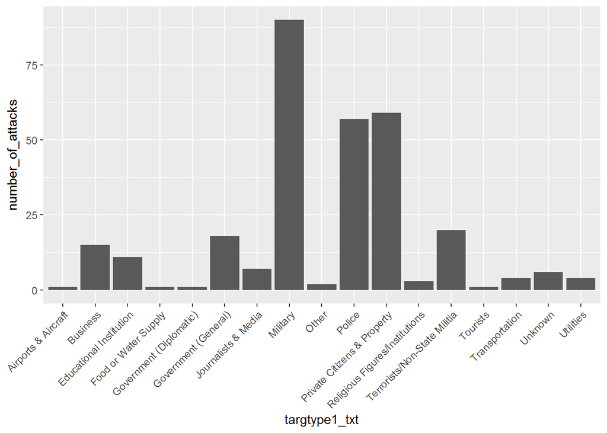

```r
#hedef
turkeydata16_hedef<-turkeydata%>%
  filter(iyear=="2016",success=="1")%>%
  group_by(targtype1_txt)%>%
  summarise(number_of_attacks=n())
ggplot(turkeydata16_hedef, aes(x=targtype1_txt,y=number_of_attacks)) +
  geom_bar(stat = "identity")+
  theme(axis.text.x=element_text(angle=45,hjust=1,vjust=1))
```